# Insight and Recommendations for baywheels

## by Caspar Heidbrink

## Berlin, 08/07/2019

## Investigation Overview

- **Growth pattern and influence of the current challenges** regarding the law suit with the Bay's Metropolitan Transportation Commission as well as the deployment of ebikes
- **Patterns of bike usage** by different user types **and opportunities to improve utilization**
- **Need for actively managing localization** of the bikes (for docks in San Francisco and East Bay)

## Dataset Overview

- Data on **bike-sharing from baywheels** by Lyft for San Francisco, East Bay and San Jose
- Offer: bikes from docks/stations (also some dockless in San Jose)
- **3.6 million recorded trips** over the last **two years/24 months** (July 2017 to June 2019)
- Each dataset comprises information about **users** (having a subscription, gender, age), **time and duration** of the trip and **start and end location**

## Overall Growth Afflicted by Current Legel and Technical Issues

- **From July 2017 to June 2019 trips per month** were more than **quadrupling** from 44.1 thousand to 191.8 thousand.
- However, **in May 2019** monthly trips were **dropping by 24%** from April's 239.1 to 182.2, which is even below January 2019's figure.
- **June 2019 has seen a slight bounce back**, which was mainly driven **by growth in non-subscriber trips**.
- Recently reported issues with **burning ebikes** as well as bad press coverage in relation to the **law suit with City** authorities may well be the **cause for this development**.

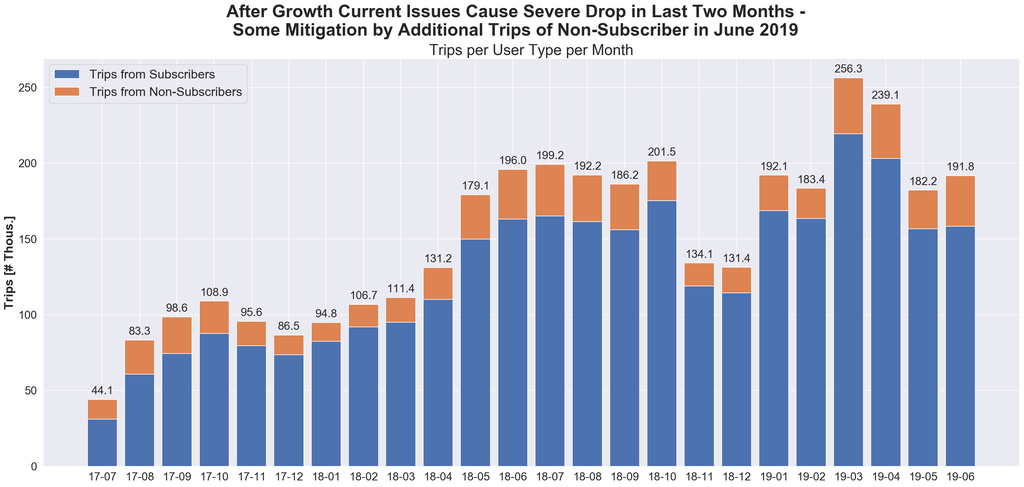

```python
# Extract relevant data for the plot
data = trip_data[['User Type', 'Month', 'Trips [Thous. #]']].sort_values('Month').copy()

# Transform data for plot
months = (data['Month']
          .drop_duplicates()
          .values)
subcribers_per_month = (data[data['User Type'] == 'Subscribers']
                        .groupby('Month')
                        .sum()
                        .values[:, 0])
non_subscribers_per_month = (data[data['User Type'] == 'Non-Subscribers']
                             .groupby('Month')
                             .sum()
                             .values[:, 0])

# Make and refine stacked bar-plot
fig, ax = plt.subplots(figsize=(28, 12))

plt.suptitle('After Growth Current Issues Cause Severe Drop in Last Two Months -\n' + \
             'Some Mitigation by Additional Trips of Non-Subscriber in June 2019',
             fontsize=28,
             fontweight='bold')

ax.bar(months,
        subcribers_per_month)
ax.bar(months,
        non_subscribers_per_month,
        bottom=subcribers_per_month)
rects = ax.bar(months, subcribers_per_month + non_subscribers_per_month, alpha=0)


ax.set_title('Trips per User Type per Month',
          fontsize=24,
          fontweight='medium')
ax.legend(['Trips from Subscribers', 'Trips from Non-Subscribers'],
           loc=2,
           fontsize=20)
ax.set_ylabel('Trips [# Thous.]',
           fontsize=20,
           fontweight='bold')
ax.set_yticklabels([0, 50, 100, 150, 200, 250], fontsize=18,
           fontweight='medium')
ax.set_xticklabels(months, fontsize=18,
           fontweight='medium')

for rect in rects:
        height = rect.get_height()
        ax.annotate('{}'.format(round(height, 1)),
                    xy=(rect.get_x() + rect.get_width() / 2, height),
                    xytext=(0, 5),
                    textcoords="offset points",
                    fontsize=18,
                    ha='center', va='bottom')
fig.show();
```

## Non-Subscribers Improve Off-Peak-Utilization (And Income!)

- In the course of a day **trips are strongly peaking** like other traffic from **8am to 9am** and from **5pm to 6pm** with an average 500-600 trips per hour.
- In between with average trips per hour around 250 utilization of the bikes is much lower.
- The strong **peaks are mainly driven by subscribers** who are probably inhabitants of the operating areas and use the bikes to ride to and from work, but are much rarely able to use the bikes during the day.
- On the other hand, **non-subscribers**, who are probably visitors to the area show a **much more stable usage pattern** over the day to do their casual trips (around an average of 50 trips per hour from 8am to 8pm).
- Therefore, **attracting more non-subscribers would help improve overall utilization**.
- As a very-positive side-effect, of course, this would generate additional income (approx. 5 USD/trip) which would be available to fund the required marketing.

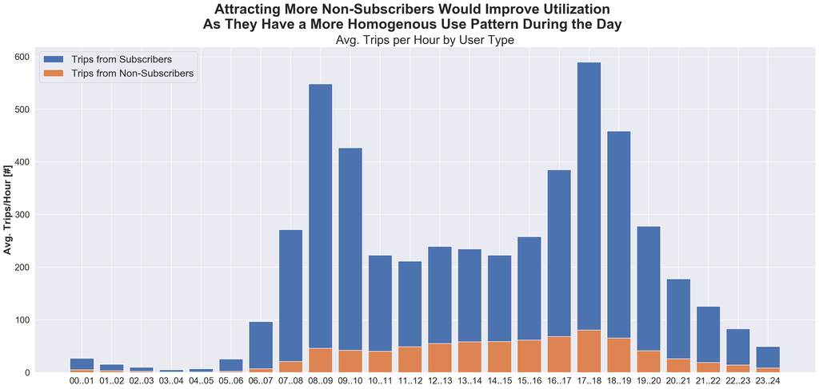

```python
# Extract relevant data for the plot
data = trip_data[['User Type', 'Hour', 'Duration [min]', 'Trips [Thous. #]']].copy()

# Transform data for plot
hours = data['Hour'].drop_duplicates().sort_values()
subscriber_per_hour = (data[data['User Type'] == 'Subscribers']
                  .groupby('Hour')
                  .sum()
                  .values[:, 1]) / (2 * 365) * 1_000
non_subscriber_per_hour = (data[data['User Type'] == 'Non-Subscribers']
                  .groupby('Hour')
                  .sum()
                  .values[:, 1]) / (2 * 365) * 1_000

# Make and refine stacked bar-plot
plt.figure(figsize=(28, 12))
plt.suptitle('Attracting More Non-Subscribers Would Improve Utilization\n' + \
             'As They Have a More Homogenous Use Pattern During the Day',
             fontsize=28,
             fontweight='bold')

plt.bar(hours, subscriber_per_hour, bottom=non_subscriber_per_hour)
plt.bar(hours, non_subscriber_per_hour)

plt.title('Avg. Trips per Hour by User Type',
          fontsize=24,
          fontweight='medium')
plt.legend(['Trips from Subscribers', 'Trips from Non-Subscribers'],
           loc=2,
           fontsize=20)
plt.ylabel('Avg. Trips/Hour [#]',
           fontsize=20,
           fontweight='bold')
plt.yticks(fontsize=18,
           fontweight='medium')
plt.xticks(fontsize=18,
           fontweight='medium')

plt.show();
```

## Allocation of Bikes Must Be Actively Managed

- Most bikes are bound to docks where the trips start/end (dockless only in San Jose).
- During the course of a day there may occur **imbalances of trips starting/ending**.
- As a consequence some docks on average **tend to being emptied or jammed**.
- This leads to the **need of an active management of bike allocation**.
- As average daily net gain/loss for **some docks** can be rather large, active allocation has to be performed **multiple times a day**.

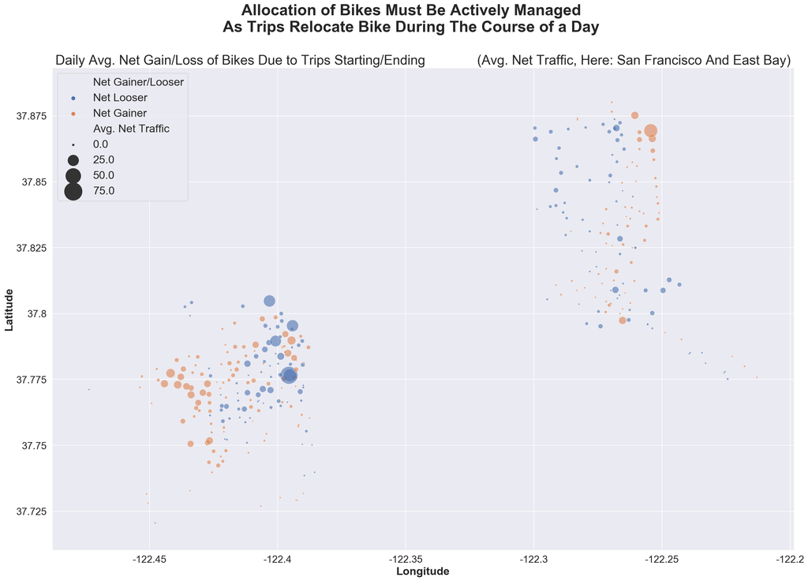

```python
# Extract relevant data for the plot
data = trip_data[trip_data['Start Area'].isin(['San Francisco', 'East Bay']) &
                 trip_data['End Area'].isin(['San Francisco', 'East Bay'])].copy()

# Transform data for plot
start_data = data[['Start Location', 'Start Latitude', 'Start Longitude', 'Trips [Thous. #]']]
start_data = start_data.groupby('Start Location').agg({'Start Latitude': 'min',
                                                       'Start Longitude': 'min',
                                                       'Trips [Thous. #]': 'sum'})
start_data['Trips [Thous. #]'] = start_data['Trips [Thous. #]'] / 365 * 1_000
start_data.columns = ['Latitude', 'Longitude', 'Avg. Daily Trips Starting']

end_data = data[['End Location', 'End Latitude', 'End Longitude', 'Trips [Thous. #]']]
end_data = end_data.groupby('End Location').agg({'End Latitude': 'min',
                                                 'End Longitude': 'min',
                                                 'Trips [Thous. #]': 'sum'})
end_data['Trips [Thous. #]'] = end_data['Trips [Thous. #]'] / 365 * 1_000
end_data.columns = ['Latitude', 'Longitude', 'Avg. Daily Trips Ending']

data = pd.merge(left=start_data,
                right=end_data,
                how='outer',
                left_index=True,
                right_index=True,
                suffixes=[' Start', ' End']).fillna(0)

data['Latitude'] = np.maximum(data['Latitude Start'], data['Latitude End'])
data['Longitude'] = np.minimum(data['Longitude Start'], data['Longitude End'])
data['Avg. Net Traffic'] = data['Avg. Daily Trips Starting'] - data['Avg. Daily Trips Ending']
data['Net Gainer/Looser'] = 'Net Gainer'
data.loc[data['Avg. Net Traffic'] < 0, 'Net Gainer/Looser'] = 'Net Looser'
data['Avg. Net Traffic'] = data['Avg. Net Traffic'].abs()

data = data[['Latitude', 'Longitude', 'Avg. Net Traffic', 'Net Gainer/Looser']]

# Make and refine stacked scatter-plot
fig, ax = plt.subplots(figsize=(24, 16))
fig.suptitle('Allocation of Bikes Must Be Actively Managed\n' + \
             'As Trips Relocate Bike During The Course of a Day',
             fontsize=28,
             fontweight='bold')
ax.set_title('Daily Avg. Net Gain/Loss of Bikes Due to Trips Starting/Ending \
             (Avg. Net Traffic, Here: San Francisco And East Bay)',
             fontsize=24,
             fontweight='medium')
sb.scatterplot(data=data,
               x='Longitude',
               y='Latitude',
               size='Avg. Net Traffic',
               sizes=(10, 1_000),
               hue='Net Gainer/Looser',
               alpha=0.6,
               ax=ax)
ax.legend(loc=2, fontsize=20)

ylabel = ax.get_ylabel()
ax.set_ylabel(ylabel,
              fontsize=20,
              fontweight='bold')
yticks = ax.get_yticks()
ax.set_yticklabels([str(round(ytick, 3)) for ytick in yticks],
                   fontsize=18,
                   fontweight='medium')
xlabel = ax.get_xlabel()
ax.set_xlabel(xlabel,
              fontsize=20,
              fontweight='bold')
xticks = ax.get_xticks()
ax.set_xticklabels([str(round(xtick, 3)) for xtick in xticks],
                   fontsize=18,
                   fontweight='medium')

plt.show();
```